# Data wrangling

Ben Whalley

September 2026

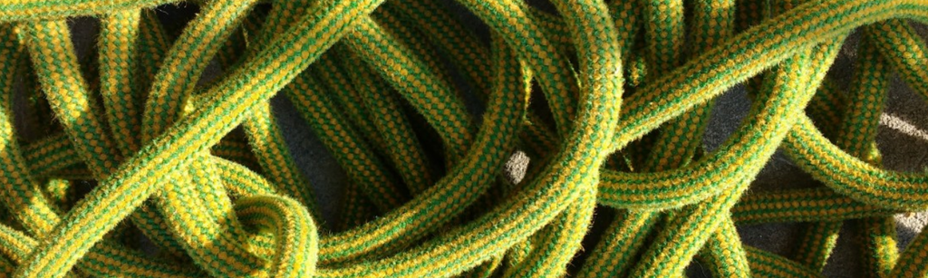

> Most time in data analysis is spent ‘tidying up’ data: getting it into a suitable format to get started. Data scientists have a particular definition of *tidy*: Tidy datasets are “easy to manipulate, model and visualize, and have a specific structure: each variable is a column, each observation is a row” (Wickham 2014). A third rule usually completes the definition: each value has its own cell.

> It’s often not convenient for humans to *enter* data in a tidy way, so untidy data is probably more common than tidy data in the wild. But doing good, reproducible science demands that we document each step of our processing in a way that others can check or repeat in future. Tools like R make this easier.

# Overview

In the [lifesavR worksheets](https://benwhalley.github.io/lifesavR/) we used various commands from the `tidyverse`, like `filter` and `group_by`.

If you want to recap these commands you could use [the cheatsheet](https://plymouthpsychology.github.io/cheatR/lifesavr_cheatsheet.html), especially the part on groups and summaries.

Today we will cover three additional techniques which are important when working with real datasets:

1. ‘Pivoting’ or reshaping data from long to wide formats (or the reverse)
2. Separating ‘untidy’ columns which contain more than one piece of information
3. Recoding text responses (e.g. from questionnaires) into numeric values

# Before you start

Make a new `rmd` file in your datafluency directory, called `data-wrangling.rmd` and record your work in this for the next 2 sessions.

# Selecting columns

As well as fuel economy (`mpg`), the `fuel` dataset contains variables for the weight and power of each car.

We can select just these columns and save them to a smaller dataframe like this:

```r
carperformance <- fuel %>%
  select(mpg, weight, power) %>%
  head()
```

#### Explanation of the commands

- On the far left we have the name of the new variable which we will create: `carperformance`.
- We can tell this will be a new variable because the `<-` symbol is just to the right, pointing at it.
- To see what `carperformance` contains, look to the right of the `<-`. We pipe the `fuel` data to the `select` command, which selects the `mpg`, `weight`, and `power` columns.
- Finally, `head()` keeps only the first 6 rows, so `carperformance` is a small preview rather than a full copy of the data.

#### Explanation of the result

When running the command you won’t see any output — but a new object was created called `carperformance` which contained copies of the columns from `fuel` we selected (for the first 6 rows only).

We can see what our new smaller dataframe contains by typing its name, or piping it to `head()` (which shows up to the first 6 rows):

```r
carperformance %>% head()
```

```
   mpg weight power
1 21.0   1188   110
2 21.0   1304   110
3 22.8   1052    93
4 21.4   1458   110
5 18.7   1560   175
6 18.1   1569   105
```

Try selecting columns in a dataset for yourself:

- Use any of the built in datasets, creating a copy with just a subset of 3 of its columns.

# Pivoting longer

Data is commonly stored in either [*wide* or *long* format](https://www.theanalysisfactor.com/wide-and-long-data/).

If you used SPSS to do a *t*-test or ANOVA during your undergraduate degree, you likely stored and analysed the data in **wide** format.

In wide format, each row represents the *observations from a single participant*. Each measurement for a given participant is stored in separate columns.

This is often called **row per subject** data. An example is the built in `attitude` dataset:

```r
attitude %>%
  head()
```

```
  rating complaints privileges learning raises critical advance
1     43         51         30       39     61       92      45
2     63         64         51       54     63       73      47
3     71         70         68       69     76       86      48
4     61         63         45       47     54       84      35
5     81         78         56       66     71       83      47
6     43         55         49       44     54       49      34
```

**Explanation**: Each row contains scores for a particular employee on various measures. To find out more about these data you can type `?attitude` into the console.

Let’s say we want a single plot of all these variables, something like this:

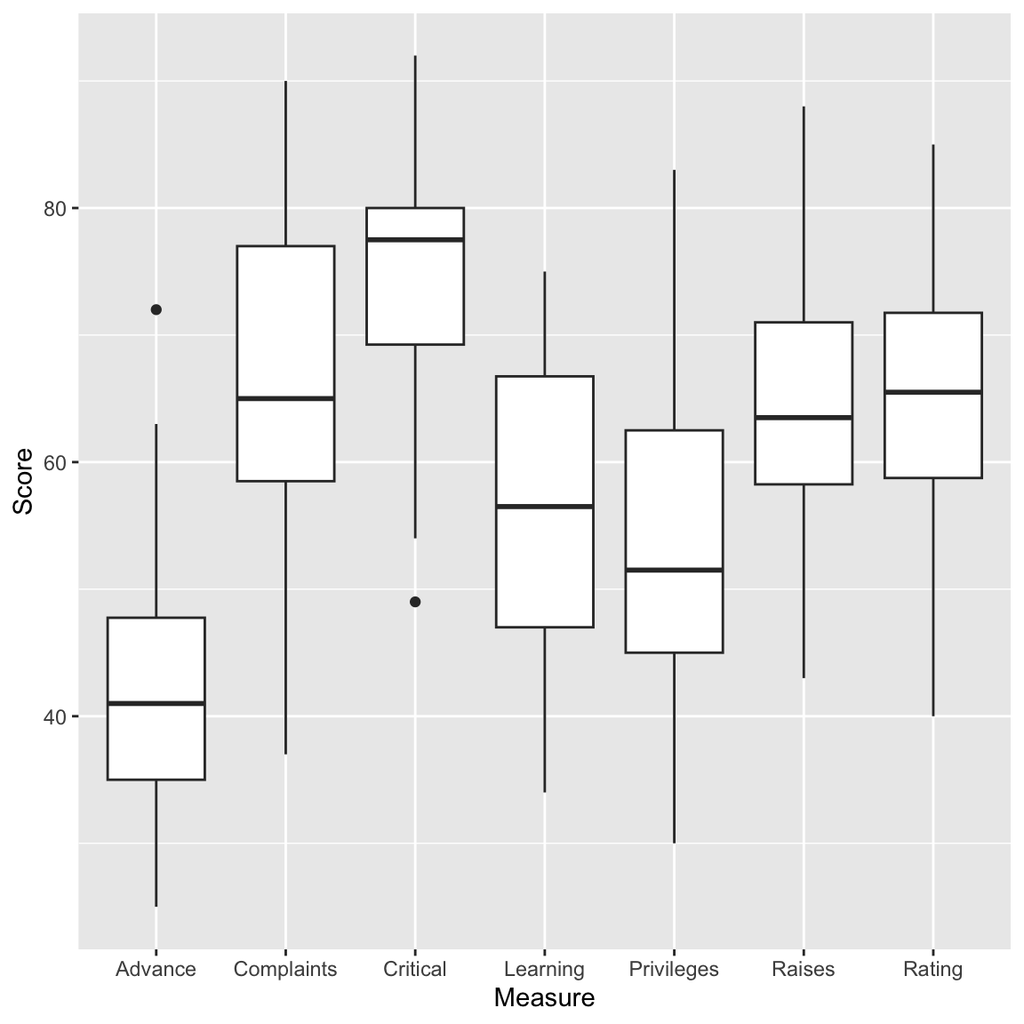

To do this we first need to convert the data to *long* format. In **long format**, each observation is saved in its own row, rather than across multiple columns.

It’s often called **“row per observation”** data.

### Using `pivot_longer()`

> Pivoting is where you take a long data file (lots of rows, few columns) and make it wider. Or where you take a wide data file (lots of columns, few rows) and make it longer.

[video not shown]

We can convert from wide to long using the `pivot_longer()` function, as shown in the video:

To see why the function is called ‘pivot_**longer**’, imagine trying to reshape just the first two rows of the attitude dataset:

```
  rating complaints privileges learning raises critical advance
1     43         51         30       39     61       92      45
2     63         64         51       54     63       73      47
```

If we use `pivot_longer` on this selection, we end up with this:

```r
attitude %>%
  head(2) %>%
  pivot_longer(everything())
```

```
# A tibble: 14 × 2
   name       value
   <chr>      <dbl>
 1 rating        43
 2 complaints    51
 3 privileges    30
 4 learning      39
 5 raises        61
 6 critical      92
 7 advance       45
 8 rating        63
 9 complaints    64
10 privileges    51
11 learning      54
12 raises        63
13 critical      73
14 advance       47
```

**Explanation of the command**: - We used `head(2)` to select just the first two rows. - Then we used `pivot_longer(everything())` to make this into long form data. - The `everything()` part tells R to pivot *all* of the columns. - By default, `pivot_longer` puts the values into a single new column called `value`, and keeps track of the original variable name in a new column called `name`.

The change works like this:

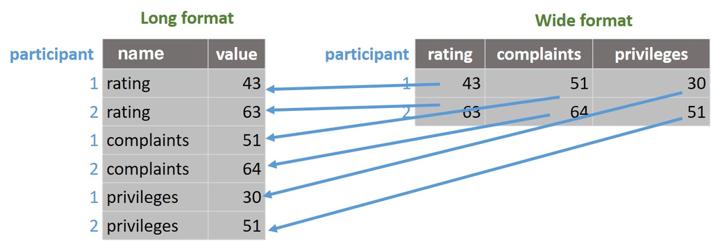

Converting from wide format to long format

You might have spotted a problem though: We don’t have a record of which participant was which in the `attitude` dataset.

This is because the mapping to participants was implicit: **each row was a different participant, but participant number was not actually recorded in the file**.

We can create an explicit participant identifier by adding a new column. For this we use the `mutate` and `row_number()` functions:

```r
attitude_with_person <- attitude %>%
  mutate(person = row_number()) %>%
  head(2)

attitude_with_person %>%
  pander()
```

| rating | complaints | privileges | learning | raises | critical | advance | person |
| --- | --- | --- | --- | --- | --- | --- | --- |
| 43 | 51 | 30 | 39 | 61 | 92 | 45 | 1 |
| 63 | 64 | 51 | 54 | 63 | 73 | 47 | 2 |

Now we have a column called `person` which stores the row number.

**But** this means if we `pivot_longer()` again, we will need to tell R *which* columns we would like to pivot.

If we don’t do this then the `person` column gets melted with everything else so we lose track of which response belonged to which participant, like this:

```r
attitude_with_person %>%
  pivot_longer(everything()) %>%
  pander()
```

| name | value |
| --- | --- |
| rating | 43 |
| complaints | 51 |
| privileges | 30 |
| learning | 39 |
| raises | 61 |
| critical | 92 |
| advance | 45 |
| person | 1 |
| rating | 63 |
| complaints | 64 |
| privileges | 51 |
| learning | 54 |
| raises | 63 |
| critical | 73 |
| advance | 47 |
| person | 2 |

**Explanation of the output** Because we didn’t tell `pivot_longer` which columns we wanted to pivot, it put all the values into a single new column called `value`. This included our participant identifier, `person` which is not what we wanted.

We can exclude `person` from the pivoting by writing:

```r
attitude_with_person %>%
  pivot_longer(-person) %>%
  head() %>%
  pander()
```

| person | name | value |
| --- | --- | --- |
| 1 | rating | 43 |
| 1 | complaints | 51 |
| 1 | privileges | 30 |
| 1 | learning | 39 |
| 1 | raises | 61 |
| 1 | critical | 92 |

**Explanation of the command and output**:

- Here, we still use `pivot_longer` but this time we put `-person` between the parentheses.
- The minus sign, `-`, means *don’t include this variable*, so `-person` ends up meaning *include all columns except `person`*, which is what we wanted.
- The output now retains the `person` column, but pivots the other variables.
- This means we can tell which person provided each datapoint.

Use some tidyverse commands you already know (e.g. `select`), plus `pivot_longer`, to produce this plot using the `attitude` dataset:

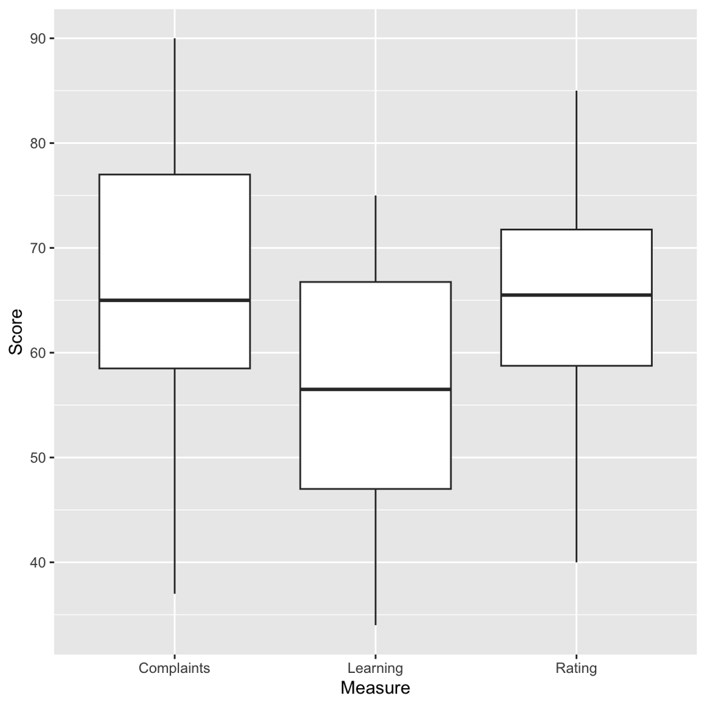

- Check the [cheatsheet](https://plymouthpsychology.github.io/cheatR/complete-cheat.html) if you get stuck
- You need to select only the three variables shown
- It’s not necessary to create a person identifier for this plot (although it won’t hurt if you do)

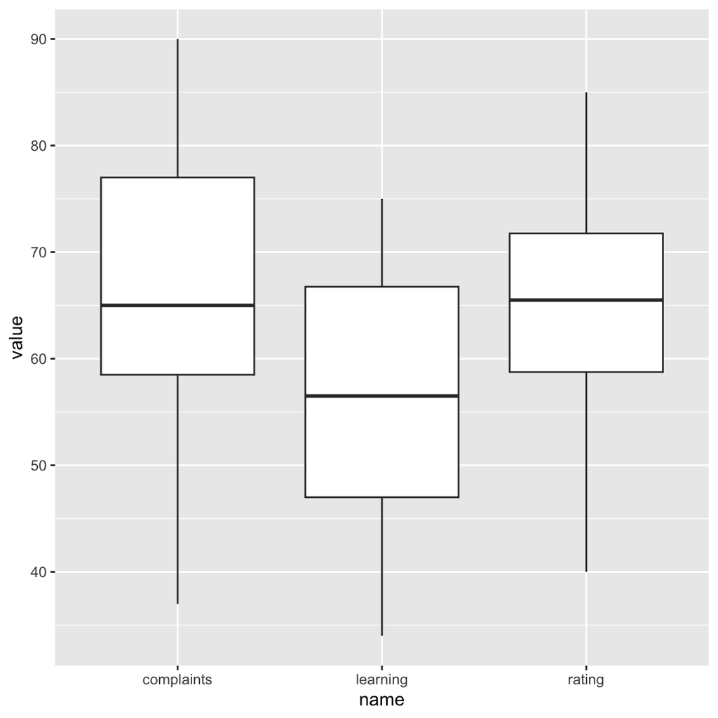

```r
attitude %>%
  select(rating, complaints, learning) %>%
  pivot_longer(everything()) %>%
  ggplot(aes(name, value)) +
  geom_boxplot()
```

# Pivoting to make summary tables

Imagine we want a table of the mean score for each question in the attitude dataset.

This would be fiddly if we just tried to use `summarise` on wide format data. But if we use `pivot_longer`, `group_by` and then `summarise` (in that order) it’s possible to take the data and make a table like this with 3 instructions to R:

| Name | Mean | SD |
| --- | --- | --- |
| advance | 42.93 | 10.29 |
| complaints | 66.6 | 13.31 |
| critical | 74.77 | 9.895 |
| learning | 56.37 | 11.74 |
| privileges | 53.13 | 12.24 |
| raises | 64.63 | 10.4 |
| rating | 64.63 | 12.17 |

Combine the `pivot_longer`, `group_by` and `summarise` commands (in that order) to reproduce the table above.

- You want to pivot *all* of the variables in the `attitude` dataset this time
- We covered using `summarise` in the [third `lifesavR` session here](https://benwhalley.github.io/lifesavR/session-3.html#groupby).

We might also want to produce summary statistics per-participant.

Using the commands shown above (and remembering to make a new column to store the participant number with `row_number()`), reproduce this table:

| person | mean(value) |
| --- | --- |
| 1 | 51.57 |
| 2 | 59.29 |
| 3 | 69.71 |
| 4 | 55.57 |
| 5 | 68.86 |

To make the table you will need to use the following functions, in roughly this order:

- mutate
- filter
- pivot_longer
- group_by
- summarise
- pander

```r
attitude %>%
  mutate(person = row_number()) %>%
  filter(person < 6) %>%
  pivot_longer(-person) %>%
  group_by(person) %>%
  summarise(mean(value)) %>%
  pander()
```

# Pivoting wider

Sometimes we have the opposite problem: We have long data, but want it in wide format. For example, we might want a table where it’s easy to compare between different years, like this:

```r
development %>%
  filter(year > 1990) %>%
  pivot_wider(id_cols=country,
              names_from=year,
              values_from=gdp_per_capita) %>%
  head(3) %>%
  pander::pander("GDP per-capita in 3 countries in 4 different years, from the development dataset.")
```

GDP per-capita in 3 countries in 4 different years, from the development dataset.

| country | 1992 | 1997 | 2002 | 2007 |
| --- | --- | --- | --- | --- |
| Afghanistan | 649.3 | 635.3 | 726.7 | 974.6 |
| Albania | 2497 | 3193 | 4604 | 5937 |
| Algeria | 5023 | 4797 | 5288 | 6223 |

**Instead of making the data longer, now we want to `pivot_wider`.**

The `development` data is a fairly long format. There are multiple rows per-country corresponding to different years.

We want to *compare* GDP in different *years*.

We first need to select the data we want — `country`, `year` and `GDP`, for the years after 1990:

```r
development1990s <- development %>%
  select(country, year, gdp_per_capita) %>%
  filter(year >= 1990)
```

Then we can `pivot_wider()`:

```r
development1990s %>%
  pivot_wider(
    names_from = year,
    values_from = gdp_per_capita
  ) %>%
  head() %>%
  pander()
```

| country | 1992 | 1997 | 2002 | 2007 |
| --- | --- | --- | --- | --- |
| Afghanistan | 649.3 | 635.3 | 726.7 | 974.6 |
| Albania | 2497 | 3193 | 4604 | 5937 |
| Algeria | 5023 | 4797 | 5288 | 6223 |
| Angola | 2628 | 2277 | 2773 | 4797 |
| Argentina | 9308 | 10967 | 8798 | 12779 |
| Australia | 23425 | 26998 | 30688 | 34435 |

**Explanation of the command and output**:

- We started with multiple rows per country, corresponding to years.
- We used `pivot_wider` with `names_from = year` to create new columns for each year in the data.
- We used `values_from=gdp_per_capita` to tell `pivot_wider` to use the GDP numbers to populate the table.
- The resulting table helps us compare years within countries, or between countries, for a given year.

Use the `funimagery` dataset in `psydata` and perform the following:

- use `select` to make a dataset with `intervention` and each of the `kg1` to `kg3` columns
- Use `pivot_longer`, `group_by` and `summarise` to calculate the average weight of participants at each timepoint
- Adapt the `group_by` function to calculate the mean at each timepoint *for each group separately*
- Add `pivot_wider` to the end of your code to create a separate column for each group.

When you finish your data should look like this:

| name | MI | FIT |
| --- | --- | --- |
| kg1 | 89.86 | 91.46 |
| kg2 | 88.62 | 86.37 |
| kg3 | 88.46 | 84.04 |

```r
funimagery %>%
  select(intervention, kg1, kg2, kg3) %>%
  pivot_longer(-intervention) %>%
  group_by(name, intervention) %>%
  summarise(M=mean(value)) %>%
  pivot_wider(names_from=intervention, values_from=M) %>%
  pander()
```

> When you run this code you may see a message like `summarise() has grouped output by 'name'`. This is just for information and can safely be ignored.

# Separating variables

Sometimes we need to separate ‘untidy’ variables into tidy, long-form data.

[video not shown]

The code below generates simulated data for 100 individuals at three time points. The format is similar to the way you might record experimental data in a spreadsheet.

```r
set.seed(1234)
N <- 100
repeatmeasuresdata <- tibble(person = 1:N,
                              time_1 = rnorm(N),
                              time_2 = rnorm(N, 1),
                              time_3 = rnorm(N, 3))

repeatmeasuresdata %>% head(8) %>%
  pander()
```

| person | time_1 | time_2 | time_3 |
| --- | --- | --- | --- |
| 1 | -1.207 | 1.415 | 3.485 |
| 2 | 0.2774 | 0.5253 | 3.697 |
| 3 | 1.084 | 1.066 | 3.186 |
| 4 | -2.346 | 0.4975 | 3.701 |
| 5 | 0.4291 | 0.174 | 3.312 |
| 6 | 0.5061 | 1.167 | 3.76 |
| 7 | -0.5747 | 0.1037 | 4.842 |
| 8 | -0.5466 | 1.168 | 4.112 |

This variable, `repeatmeasuresdata`, is in **wide** format. Each row contains data for one participant, and each participant has three observations.

As we saw previously, we can *pivot* — i.e., reshape — the data into longer format like so:

```r
repeatmeasuresdata %>%
  pivot_longer(starts_with("time")) %>%
  arrange(person, name) %>%
  head(8) %>%
  pander()
```

| person | name | value |
| --- | --- | --- |
| 1 | time_1 | -1.207 |
| 1 | time_2 | 1.415 |
| 1 | time_3 | 3.485 |
| 2 | time_1 | 0.2774 |
| 2 | time_2 | 0.5253 |
| 2 | time_3 | 3.697 |
| 3 | time_1 | 1.084 |
| 3 | time_2 | 1.066 |

The problem we have now is that `name` contains text which describes at which time the observation was made. We probably want to store a *number* for each time-point, so we can make a plot with time on the x axis.

The `separate` command separates a single character column (`name`) into multiple columns. Rather than have a column with labels of the form ‘time_1’, it can create two columns, with labels ‘time’ and ‘1’ in each. Adding `convert = TRUE` tells R to convert the new columns to numbers where it can.

```r
# convert to long form; extract the `time` as a new numeric column
longrepeatmeasuresdata <- repeatmeasuresdata %>%
  pivot_longer(starts_with("time")) %>%
  separate(name, into = c("variable", "time"), convert = TRUE)

longrepeatmeasuresdata %>% head %>%
  pander()
```

| person | variable | time | value |
| --- | --- | --- | --- |
| 1 | time | 1 | -1.207 |
| 1 | time | 2 | 1.415 |
| 1 | time | 3 | 3.485 |
| 2 | time | 1 | 0.2774 |
| 2 | time | 2 | 0.5253 |
| 2 | time | 3 | 3.697 |

Now the data are in long format, we can plot the points over time:

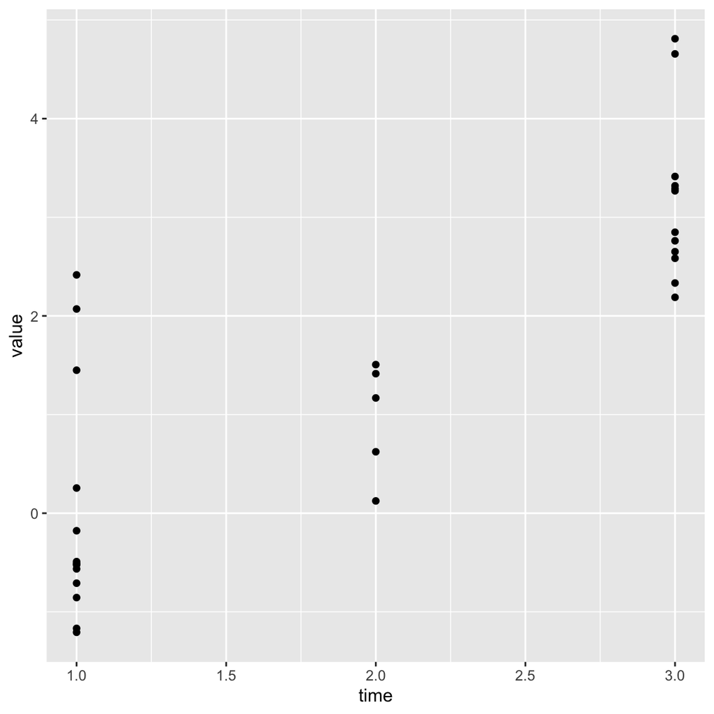

```r
longrepeatmeasuresdata %>%
  slice_sample(n = 30) %>%
  ggplot(aes(x=time, y=value)) +
  geom_point()
```

### How does R know where to split the text?

In the example above, `separate` split data like `"time_1"`, `"time_2"` etc into two columns: `variable` and `time`.

Q: How did it know to use the underscore (`_`) to split the data?

A: By default, `separate` splits wherever it finds a character which is not a letter or number. So `_`, a space, or `,` would all work.

Sometimes though we need to tell R explicitly what to use to separate the values.

If we had a column of email addresses we could split `ben.whalley@plymouth.ac.uk` into the username (e.g. `ben.whalley`) and domain name (`plymouth.ac.uk`) using the `@` symbol.

To do this we just write `sep="@"` when we use separate.

Newer versions of `tidyr` also include `separate_wider_delim()`, which does the same job but always requires you to say explicitly what to split on (e.g. `separate_wider_delim(name, delim = "_", names = c("variable", "time"))`). You may see this in other people’s code; `separate` still works fine for everything in this worksheet.

The `messy_exp` dataset in `psydata` contains simulated RT data on 100 participants in 2 conditions (A and B) at three time points (1, 2, and 3).

- Use the `separate()` function to split up the `condition` variable in this dataset and draw the following plot:

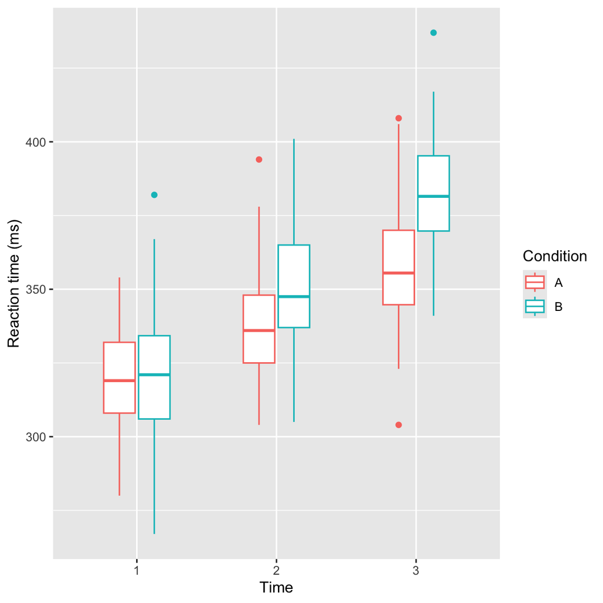

```r
messy_exp %>%
  separate(condition, into=c("participant", "condition", "time")) %>%
  ggplot(aes(time, rt, color=condition)) +
  geom_boxplot(width=.5) +
  labs(x="Time", y="Reaction time (ms)", color="Condition")
```

> Note, you will need to use `sep="@"` to split the email addresses at the `@` symbol
2. Use the `distinct` and/or `count` functions on the new variable you create containing the domain name. Look them up in the help file if you don’t know which to use to answer these questions:
- How many people had a Gmail account?
- Which domains had more than 10 users?

```r
# read the data directly from the URL
contacts <- read_csv('https://benwhalley.github.io/datafluency/data/100-contacts.csv') %>%
  separate(email, into=c("user", "domain"), sep ="@")  # uses the @ symbol as a separator
```

```r
# how many _different_ domains are there?
contacts %>%
  distinct(domain) %>%
  count() %>%
  pander()
```

| n |
| --- |
| 39 |

```r
# how many people use gmail
contacts %>%
  count(domain) %>%
  filter(domain=="gmail.com") %>%
  pander()
```

| domain | n |
| --- | --- |
| gmail.com | 16 |

```r
# which domains had more than 10 users?
contacts %>%
  count(domain) %>%
  filter(n > 10) %>%
  pander()
```

| domain | n |
| --- | --- |
| aol.com | 13 |
| gmail.com | 16 |
| hotmail.com | 13 |
| yahoo.com | 13 |

# Questionnaire data

The file `sweets.csv` contains a small number of example rows of data exported from an online survey.

The file is at: https://is.gd/axenun

We can look at the first few rows of the data, using the `glimpse` command:

```r
sweets <- read_csv('https://is.gd/axenun')
sweets %>% glimpse()
```

```
Rows: 4
Columns: 8
$ ID                               <dbl> 6, 7, 8, 9
$ `Start time`                     <dttm> 2019-05-24 09:12:31, 2019-05-24 09:12…
$ `Completion time`                <dttm> 2019-05-24 09:12:35, 2019-05-24 09:1…
$ Email                            <chr> "anonymous", "anonymous", "anonymous…
$ Name                             <lgl> NA, NA, NA, NA
$ `How much do you like sweets?`   <chr> "I don't like them", "I'm neutral", "…
$ `How much do you like chocolate` <chr> "I don't like them", "I don't like th…
$ Gender                           <chr> "M", "F", "M", "F"
```

- Import the sweets data as shown above from: https://is.gd/axenun
- Save it to a new variable called `sweets`

## Tidying questionnaires

When we look at the imported data it’s useful to note:

1. There are extra columns we don’t need (at least for now).
2. Some of our variable names are very long and annoying to type (for example `How much do you like sweets?` is the name of one of our columns).
3. Our responses are in **text** format, rather than as numbers. For example, the data say `"I don't like them"` or `"I'm neutral"` rather than numbers from a 1-5 scale.

We need to sort each of these problems to make things more manageable for our analysis.

## Selecting and renaming

> Remember, R makes using columns with spaces or other special characters very hard. We want to avoid this.

### Selecting

To use columns with spaces in we must ‘escape’ the spaces and **let R know they are part of the name** rather than a gap between two different names.

This video shows how (or read below):

[video not shown]

To escape spaces and use columns with long names we use the backtick character (the backwards facing apostrophe) to *wrap* the column name.

**In general, if your columns contain spaces or other odd characters like hyphens or question marks then you will need to wrap them in backticks.**

### Renaming

Some of the imported variable names in the `sweets` data are long and awkward to use.

Most researchers would rename these variables, to make them more usable in R code.

You can rename variables like this:

```r
datasetname %>%
  rename(NEW_COLUMN_NAME = OLD_COLUMN_NAME)
```

So for this example:

```r
sweets %>%
  rename(
    like_sweets = `How much do you like sweets?`,
    like_chocolate = `How much do you like chocolate`
  )
```

```
# A tibble: 4 × 8
     ID `Start time`        `Completion time`   Email     Name  like_sweets
  <dbl> <dttm>              <dttm>              <chr>     <lgl> <chr>
1     6 2019-05-24 09:12:31 2019-05-24 09:12:35 anonymous NA    I don't like th…
2     7 2019-05-24 09:12:31 2019-05-24 09:12:35 anonymous NA    I'm neutral
3     8 2019-05-24 09:12:31 2019-05-24 09:12:35 anonymous NA    I like them
4     9 2019-05-24 09:12:31 2019-05-24 09:12:35 anonymous NA    I'm neutral
# ℹ 2 more variables: like_chocolate <chr>, Gender <chr>
```

**Explanation of the code**: We used `rename` to change the names of our variables. We needed to wrap the long names of the questions in ‘backtick’ symbols to make sure R understood it was a single column name.

You should create a new variable to save the renamed dataset (with a descriptive name for use later on):

```r
# create a new variable containing the renamed dataset
sweets.renamed <- sweets %>%
  rename(
    like_sweets = `How much do you like sweets?`
)
```

1. Create a copy of the sweets data in which you have selected only the two columns with long names.
2. Create a second copy of the data where you have renamed the columns with long names to something short, and without spaces.

### Renaming with the `janitor` package

A good alternative to renaming variables manually is to use the `clean_names` function in the `janitor` package.

```r
sweets %>%
  janitor::clean_names() %>%
  glimpse
```

```
Rows: 4
Columns: 8
$ id                             <dbl> 6, 7, 8, 9
$ start_time                     <dttm> 2019-05-24 09:12:31, 2019-05-24 09:12:3…
$ completion_time                <dttm> 2019-05-24 09:12:35, 2019-05-24 09:12:…
$ email                          <chr> "anonymous", "anonymous", "anonymous",…
$ name                           <lgl> NA, NA, NA, NA
$ how_much_do_you_like_sweets    <chr> "I don't like them", "I'm neutral", "I …
$ how_much_do_you_like_chocolate <chr> "I don't like them", "I don't like them…
$ gender                         <chr> "M", "F", "M", "F"
```

**Explanation of the code and result**. I used the `clean_names` function within the `janitor` package without using `library`. I did this by typing `janitor::` and then the name of the function. In the result `clean_names` has made a new dataset:

- Removed all special characters
- Made everything lower case (easier for R to autocomplete)
- Replaced spaces with underscores
- Made column names unique (this isn’t always the case with imported data, but is important for R)

I typically use this function when importing any new data because it makes the naming and access of columns much more consistent and easier to remember.

# Recoding text

We noticed above that our responses were stored as text labels like `"I don't like them"` rather than on a numeric scale. This makes it hard to use in an analysis.

**We need to *recode* the text variables into numeric versions.**

### How to do it

First we must tell R what number we want to use for each text label. That is, we create a *mapping of numbers to labels*.

This takes a few steps:

1. Check **exactly** what the text values are which need to be mapped.
2. Make a **mapping variable** which assigns each text value a number value
3. Use the `recode` function with `mutate` to create a new, numeric column

This video walks you through the steps below:

[video not shown]

### Step 1: Check EXACTLY what text labels we have

To check which labels we need to recode, I select the column in question and use the `unique()` function.

```r
# check exactly what text values are in the dataset?
sweets %>%
  select(`How much do you like sweets?`) %>%
  unique()
```

```
# A tibble: 3 × 1
  `How much do you like sweets?`
  <chr>
1 I don't like them
2 I'm neutral
3 I like them
```

Do the same to find out the possible values of the `How much do you like chocolate` column.

```r
sweets %>%
  select(`How much do you like chocolate`) %>%
  distinct() %>%
  pander()
```

| How much do you like chocolate |
| --- |
| I don’t like them |
| I’m neutral |

Here I used `distinct()`, which is the tidyverse equivalent of `unique()`: both give the same result.

### Step 2: Make a mapping variable

We do this by creating what R calls a **named vector**, which is a special kind of list.

To make a named vector we use the `c()` function. The letter `c` here just stands for ‘combine’ — i.e. ‘combine these things into a list’.

This is a simple example:

```r
mapping.list <- c("No" = 0, "Yes" = 1)
```

We could then use this mapping to recode a column of data which contained the words “No” or “Yes”.

*A useful trick* when creating your own mappings is to use R to do the formatting for you (see the video above for a demo).

Re-using the code from the previous step, we use `unique()` to show us the *unique values* for the question about sweets.

We then pipe the result to the `paste()` and `cat()` functions, like this:

```r
# the hack we use as a short-cut to creating a mapping variable
sweets %>%
  select(`How much do you like sweets?`) %>%
  unique() %>%
  paste() %>% cat()
```

```
c("I don't like them", "I'm neutral", "I like them")
```

**Explanation of the output**: Using `paste` and `cat` is a bit of a hack. When we run this code we see the output `c("I don't like them", "I'm neutral", "I like them")`. This is a list of the values in the `sweets` data for this question, formatted in a way that will be useful to us in the next step.

We then copy and paste this output into a NEW code block, and EDIT it to assign our mappings:

```r
preference.mappings <- c("I don't like them" = -1, "I'm neutral" = 0, "I like them" = 1)
```

**Explanation of the code**: We used the previous output to create a mapping. By adding the parts which read `= -1` and `= 0` etc, we have told R what value we want to assign for each label.

Q: How do you know what number values to assign?

A: It doesn’t matter, provided:

- The intervals between each options are the same and
- Each text value has a different number

So, if we had a Likert-scale ranging from “Completely agree” to “Completely disagree” in 7 increments, we could score this from `0 - 6` or `1 - 7`, or `-3 - 3`. These would all be fine.

### Step 3: Use the mapping variable to recode the column

We can use our new mapping with the `mutate` and `recode` functions to make a **new column**, containing numbers rather than text:

```r
sweets.recoded <-  sweets %>%
    rename(
      like_sweets = `How much do you like sweets?`,
      like_chocolate = `How much do you like chocolate`
    ) %>%
    # use recode to convert text response using preference.mappings
    mutate(
        like_sweets_numeric =
            recode(like_sweets, !!!preference.mappings)
    )
```

We can see this new column if we use `glimpse`:

```r
sweets.recoded %>% glimpse()
```

```
Rows: 4
Columns: 9
$ ID                  <dbl> 6, 7, 8, 9
$ `Start time`        <dttm> 2019-05-24 09:12:31, 2019-05-24 09:12:31, 2019-05-…
$ `Completion time`   <dttm> 2019-05-24 09:12:35, 2019-05-24 09:12:35, 2019-05…
$ Email               <chr> "anonymous", "anonymous", "anonymous", "anonymous"
$ Name                <lgl> NA, NA, NA, NA
$ like_sweets         <chr> "I don't like them", "I'm neutral", "I like them"…
$ like_chocolate      <chr> "I don't like them", "I don't like them", "I'm neu…
$ Gender              <chr> "M", "F", "M", "F"
$ like_sweets_numeric <dbl> -1, 0, 1, 0
```

**Explanation of the code**:

- The start of the first line is `sweets.recoded <-` which means make a new variable called `sweets.recoded`.
- Then we use `mutate` to create a **new** column called `like_sweets_numeric`.
- We make this column using `recode` on the question about liking sweets.
- We use the `preference.mappings` mapping to specify what numeric score to give each of the text values.

**Watch out for the exclamation marks`!!!`**: In the code above there are three exclamation marks, `!!!`, before the mapping; make sure you do the same.

*Note*: `recode` still works, but newer versions of `dplyr` recommend `case_match()` for the same job. You don’t need to learn it now, but you may see it in other people’s code.

### Three exclamation marks: `!!!`

*Understanding this isn’t necessary to get on with the course. Only read this if you are interested!*

In the code above when we used `recode` we used three exclamation marks just before our list.

We defined the mapping:

```r
likert.responses <- c(
            "I hate them" = 1,
            "I don't like them" = 2,
            "I'm neutral" = 3,
            "I like them" = 4,
            "I can't live without them" = 5)
```

And then used it with `recode`, with the three exclamation marks.

```r
liking_of_sweets_data %>%
    mutate(like_sweets_numeric = recode(like_sweets_text, !!!likert.responses)) %>%
  pander()
```

The reason for this is that `recode` actually expects us to specify the mapping for it like this:

```r
liking_of_sweets_data %>%
    mutate(like_sweets_numeric = recode(like_sweets_text,
        "I hate them" = 1,
        "I don't like them" = 2 ...))
```

But this means we have to repeat the mapping for each of the questions. Because all the questions use the same mapping this gets repetitive, and can lead to errors.

The three exclamation marks `!!!` *unpacks* the list for us. So writing `!!!likert.responses` saves us the bother of writing it out in full each time.

### Summary/video explanation

This is one of the trickiest bits of R code we use. I’ve included an annotated video of just these steps as a reference below:

[video not shown]

- Use this three-step process to create a recoded version of the `like_chocolate` variable.
- Remember to watch the video at the start of this section, or the summary video above, if anything is unclear.

# Combining scores

Often questionnaires are designed to make repeated measurements of the same phenomena, which can then be summed or averaged to create a more reliable measure.

We’ve already seen how `mutate()` creates a new column. We can use this again to create the *sum* of responses to both questions:

```r
sweets.recoded %>%
  # mutate to create column containing sum of both recoded questions
  mutate(liking = like_sweets_numeric + like_chocolate_numeric) %>%
  # select the new variable we created
  select(ID, liking) %>%
  pander()
```

| ID | liking |
| --- | --- |
| 6 | -2 |
| 7 | -1 |
| 8 | 1 |
| 9 | 0 |

**Explanation of the code**:

- We added both the questions which asked about ‘liking’ together. This created a new column containing the combined score, called `liking`.
- In the third line we selected only the `ID` column, plus the new column we made.

# Using AI chatbots to automate things

In the sections above I explained how to tidy up a simple dataset. However it turns out many of these tasks can be solved quickly using AI chatbots (large language models, or LLMs) such as ChatGPT, Claude or Gemini, or the assistants now built into RStudio and Positron.

You now have a choice you didn’t have a few years ago:

1. Learn how to do these steps by hand (and sometimes use an LLM to automate the work)
2. Learn just enough to be able to get an LLM to write code for you (and hope it’s correct)

I would recommend option 1 because you need to understand the code to check it is correct, and it will promote your understanding.

But as a guide, here’s how I might solve this problem with ChatGPT as an assistant (other tools work in much the same way).

**Never paste identifiable or confidential participant data into a chatbot.** Share only column names, a few made-up example rows, or summaries like the ones below, and check your university’s guidance on using AI tools with research data.

#### Step 1. Show ChatGPT the data

I use these commands to output some information about the data, in a format that’s easy to copy into ChatGPT.

```r
sweets <- read_csv('https://is.gd/axenun')

# lists the column names
sweets %>% names()

sweets %>% glimpse()

# list the unique values in response to this question
sweets %>% count(`How much do you like sweets?`) %>%
  pander()
```

#### Step 2: Ask ChatGPT to recode it for us

This link shows how I asked ChatGPT to recode the `sweets` data:

https://chatgpt.com/share/325b1f77-c68c-417a-8e75-76b05a6b9633

Note that I:

- told it the names of the columns
- showed it a sample of the data (pasted in the output of `glimpse`)
- explicitly listed the values in the columns I wanted to recode (pasted in output of `count`)
- directly asked for R code
- gave instructions to use the tidyverse (this makes the output more consistent with what you have learned)

#### Step 3: Debug and validate the R code ChatGPT provides

[figure not shown]

In this example, ChatGPT provided the following code:

```r
library(tidyverse)

# Load the sweets dataset (assuming it's already loaded)
sweets <- read_csv('https://is.gd/axenun')

# Recode the text responses into numeric variables
sweets <- sweets %>%
  mutate(Like_sweets = recode(`How much do you like sweets?`,
    "I don't like them" = 0,
    "I like them" = 1,
    "I'm neutral" = 2
  )) %>%
  mutate(Like_chocolate = recode(`How much do you like chocolate`,
    "I don't like them" = 0,
    "I like them" = 1,
    "I'm neutral" = 2
  )) %>%
  select(-`How much do you like sweets?`, -`How much do you like chocolate`)

# Rename variables with spaces to use underscores and be shorter
sweets <- sweets %>%
  rename(
    ID = `ID`,
    Start_time = `Start time`,
    Gender = `Gender`
  )

# Remove timestamp and email columns
sweets <- sweets %>%
  select(-`Start_time`, -`Email`)

# Check the modified dataset
glimpse(sweets)
```

This code runs without any errors. **But it is wrong.** Look carefully at the numbers ChatGPT assigned:

- `"I don't like them"` = 0
- `"I like them"` = 1
- `"I'm neutral"` = 2

This scores being neutral *higher* than liking sweets. The responses are ordered (don’t like < neutral < like), so the numbers should be too. The mapping should have been:

```r
"I don't like them" = 0,
"I'm neutral" = 1,
"I like them" = 2
```

If we hadn’t checked, we would have calculated averages and summary scores that looked plausible but were meaningless.

**This is the key lesson: code that runs is not necessarily code that is correct.** R will happily do the wrong thing if you ask it to. You must read and check any code an LLM gives you, just as you would check your own.

It’s also worth saying that LLM code *often* doesn’t work on first try, and it is dependent on writing a good prompt to the model, and giving it plenty of information about the data and what you want to achieve.

Some tips:

- Think first. Be clear about what you want to achieve.
- Explain in detail what the data are like and show examples.
- Give explicit instructions.
- If code doesn’t work, ask for explanations or corrections.
- Break tasks down into smaller steps (ask for less and build up your script).
- Paste in the code you already have and ask for a completion with one extra step (e.g. something you don’t know how to do).
- Always check the output (e.g. with `glimpse` or `count`) to make sure it has done what you intended.

Where there are bugs in an LLM’s code, you can

- fix these bugs by hand, or
- run the code, report the errors to the LLM and ask it to fix them for you.

The second option has some risks (the code *might* delete or overwrite your data, although it’s unlikely), and is often slower. In this instance it took me quite a while to get ChatGPT to fix the simple errors, and this required understanding the code to some degree anyway. And as we saw above, some mistakes don’t produce errors at all: you only find them by reading the code.

As I recommend in the lectures, knowing how to use R well enough to fix the small errors introduced is likely to be more productive in the long run. Think of LLMs as your assistant rather than your replacement.

# Consolidation activity

Use this example dataset: https://is.gd/ayinof

- Read in the data.
- Rename the long column names to something short, and without spaces
- Recode at least three of the columns with data about sleep quality to be numeric
- Save the result of this work in a new variable called `sleep.tidy`
- Pivot the recoded variables and make a boxplot of responses to these questions
- Create a summary score called `sleep_problems` which is the sum of these recoded questions (use mutate)
- Create a density plot of this summary score and interpret what you see (describe the pattern in plain English)

```r
sleep <- read_csv('https://is.gd/ayinof')

# used to check what response values are in each question
sleep %>%
  select(`My sleep is affected by my study commitments`) %>%
  unique() %>% paste %>% cat
```

```
c("Agree", "Somewhat agree", "Somewhat disagree", "Disagree", "Neither agree nor disagree", "Strongly agree", "Strongly disagree")
```

```r
sleep %>%
  select(`My electronic device usage negatively affects my sleep`) %>%
  unique() %>% paste %>% cat
```

```
c("Disagree", "Strongly agree", "Somewhat disagree", "Agree", "Somewhat agree", "Neither agree nor disagree", "Strongly disagree")
```

```r
sleep %>%
  select(`My sleep is disturbed by external factors e.g. loud cars, housemates, lights, children...`) %>%
  unique() %>% paste %>% cat
```

```
c("Strongly agree", "Disagree", "Somewhat disagree", "Somewhat agree", "Agree", "Strongly disagree", "Neither agree nor disagree")
```

```r
# we will use the same mapping for all three questions because they have the same responses
sleep.map <- c("Agree"=2,
               "Somewhat agree"=1,
               "Somewhat disagree"=-1,
               "Disagree"=-2,
               "Neither agree nor disagree"=0,
               "Strongly agree"=3,
               "Strongly disagree"=-3)


sleep.tidy <- sleep %>%
  # now we recode the three text variables (we only need use mutate once though)
  mutate(
    sleep_study = recode(`My sleep is affected by my study commitments`, !!!sleep.map),
    sleep_electronic = recode(`My electronic device usage negatively affects my sleep`, !!!sleep.map),
    sleep_disturbed = recode(`My sleep is disturbed by external factors e.g. loud cars, housemates, lights, children...`, !!!sleep.map)
  )
```

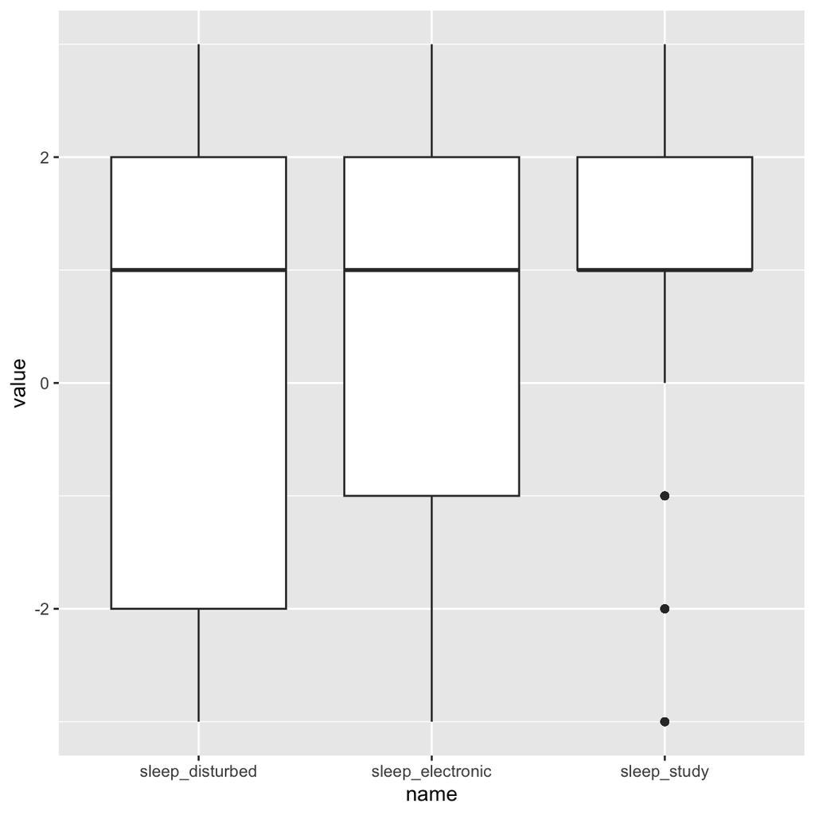

```r
# now we can pivot longer to make a plot
sleep.tidy %>%
  pivot_longer(c(sleep_study, sleep_electronic, sleep_disturbed)) %>%
  ggplot(aes(name, value)) + geom_boxplot()
```

And make a summary score combining the three questions. All three items ask whether something *affects* or *disturbs* sleep, so agreeing means more sleep problems. That’s why I’ve called the score `sleep_problems`: higher scores mean *worse* sleep.

```r
sleep.tidy.withsummary <- sleep.tidy %>%
  # and create the summary score
  mutate(sleep_problems = sleep_study + sleep_electronic + sleep_disturbed)

# check the result. it looks ok
sleep.tidy.withsummary %>% glimpse
```

```
Rows: 241
Columns: 14
$ uniqueid                                                                                    <chr> …
$ `Start time`                                                                                <dttm> …
$ `Completion time`                                                                           <dttm> …
$ `My sleep is affected by my study commitments`                                              <chr> …
$ `I achieve good quality sleep`                                                              <chr> …
$ `My electronic device usage negatively affects my sleep`                                    <chr> …
$ `Tiredness interferes with my concentration`                                                <chr> …
$ `My sleep is disturbed by external factors e.g. loud cars, housemates, lights, children...` <chr> …
$ `I often achieve eight hours of sleep`                                                      <chr> …
$ `I regularly stay up past 11pm`                                                             <chr> …
$ sleep_study                                                                                 <dbl> …
$ sleep_electronic                                                                            <dbl> …
$ sleep_disturbed                                                                             <dbl> …
$ sleep_problems                                                                              <dbl> …
```

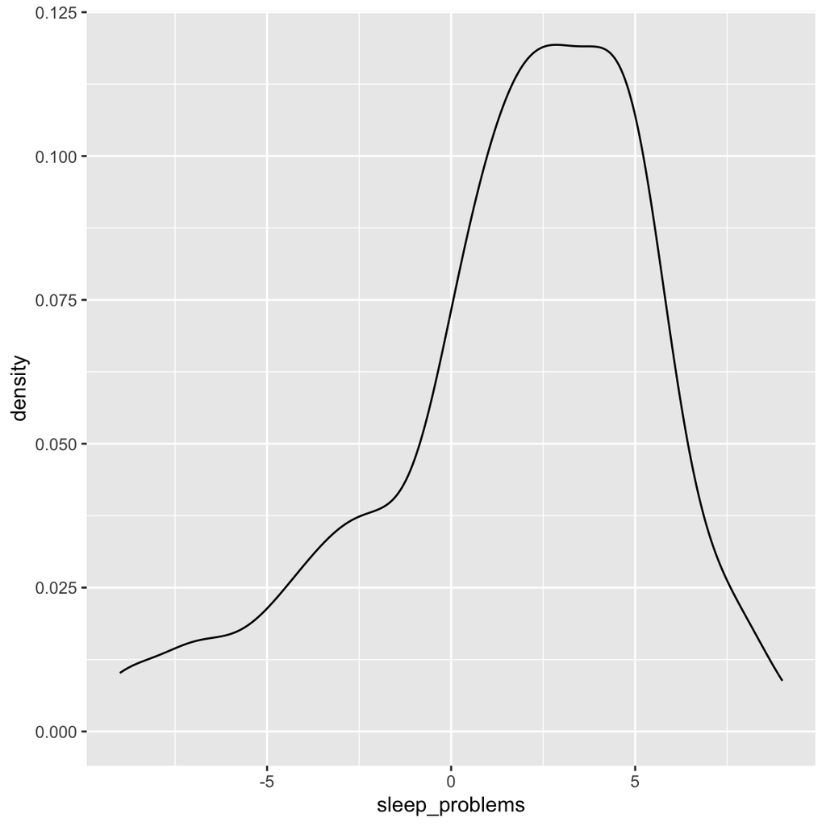

```r
# finally, make the requested density plot
# make the density plot
sleep.tidy.withsummary %>%
  ggplot(aes(sleep_problems)) +
  geom_density()
```

# Check your knowledge

- What does it mean for data to be “tidy”? Identify the three key characteristics
- What function creates a new column in a dataset?
- Which function allows you to choose a subset of the columns in a dataset?
- What does `pivot_longer` do?
- Why is `pivot_longer` useful when we want to make a faceted plot? (Think back to the facets we used in the visualisation session.)
- Why is wide data sometimes more useful than long data?
- If you have RT data with 10 groups, what tidyverse ‘verbs’ (functions) would you use to calculate the mean for each group?
- How can you read data into a dataframe from over the internet?
- In this worksheet we used `recode` with a mapping variable. What type of values did we start with, and what type did we end up with?
- Why is it important to recode text variables into numeric values when working with survey or questionnaire data?
- Why is it important to copy and paste exact values when making a mapping variable for `recode`?
- When renaming, is it: `rename(oldvarname=newvarname)` or `rename(newvarname=oldvarname)`?
- What does the `clean_names` function from the janitor package do?
- Imagine a single cell of your dataset contains the string “conditionA_time_1”. What function should we apply to it?

Wickham, Hadley. 2014. “Tidy Data.” *Journal of Statistical Software* 59 (1): 1–23. https://doi.org/10.18637/jss.v059.i10.